# Final Project - Predicting Shelter Animal Outcomes

Mason Ogden

6/5/2021

## Overview and Exploratory Data Analysis

In [this](https://www.kaggle.com/c/shelter-animal-outcomes/data) Kaggle competition, participants were asked to predict the outcome of shelter animals in the Austin area. The data was collected between 2013 and 2016, and contained information on 38,185 cats and dogs (26,729 in the training set, 11,456 in the testing set). For pets in these shelters, there were five possible outcomes: adoption, returned to owner, transferred to another shelter, euthanasia, or death. Figure 1 shows how many pets experienced each outcome in the training data.

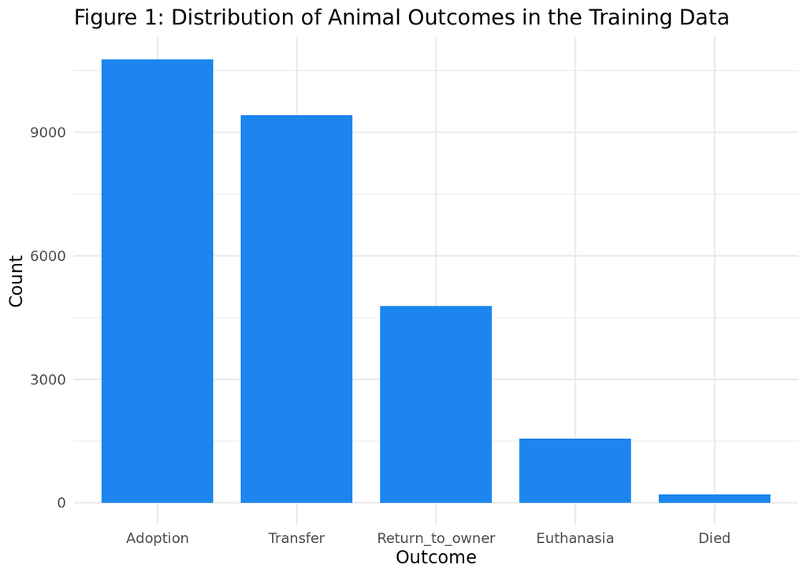

Various attribues of the pets were also recorded. The first and most obvious is whether the pet was a cat or a dog. The proportion of cats and dogs can be seen in Figure 2. There is quite an imbalance in these proportions, with 58% of the animals being dogs and only 42% being cats.

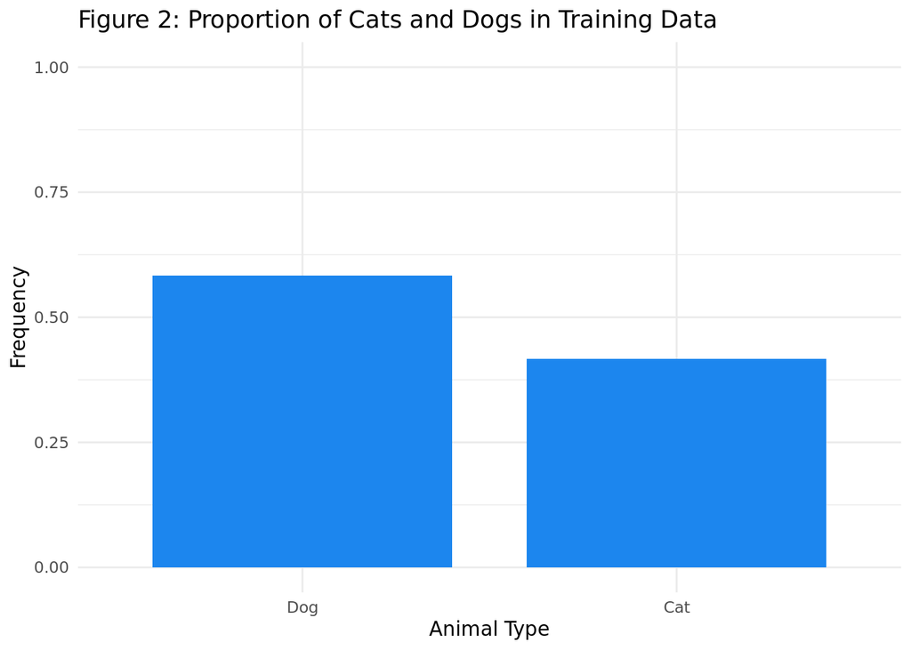

Additionally, the sex of each pet was recorded, including whether they were spayed or neutered. Figure 3 shows the counts of each sex, as well as how many within each sex were spayed or neutered. There were also 1074 pets for which their sex was unknown. It’s clear from the figure that the majority of both male and female pets were spayed or neutered.

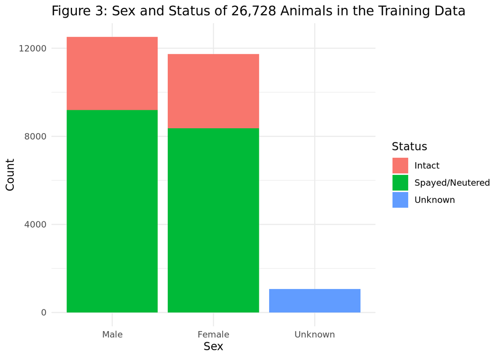

The age of each pet was also recorded. The distribution of pet ages (shown in Figure 4) is very right-skewed, with most pets being in the 0 - 2 years old range, and few very old pets.

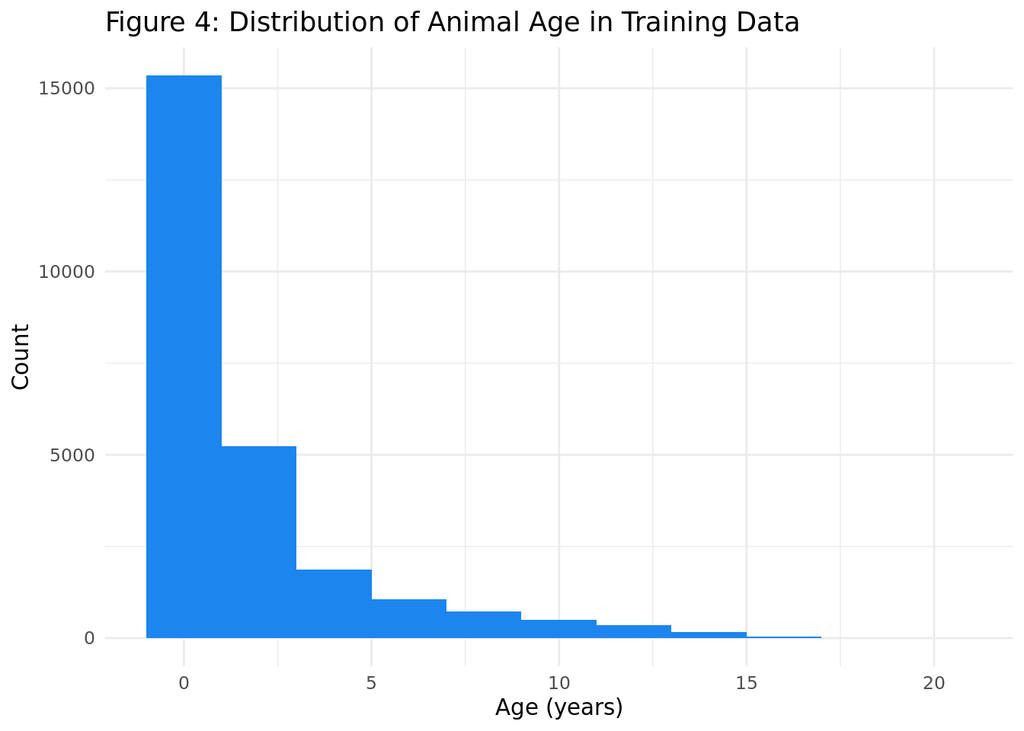

There was also a ‘breed’ column in the data that contained extremely specific information about the genealogy of each pet. There were 1380 unique breeds in the data, which was far too many to effectively include the variable in any model. This variable was dropped from the data, since collapsing categories would have been extremely time-consuming, and would require extensive knowledge of dogs, which I do not have, having never owned a pet.

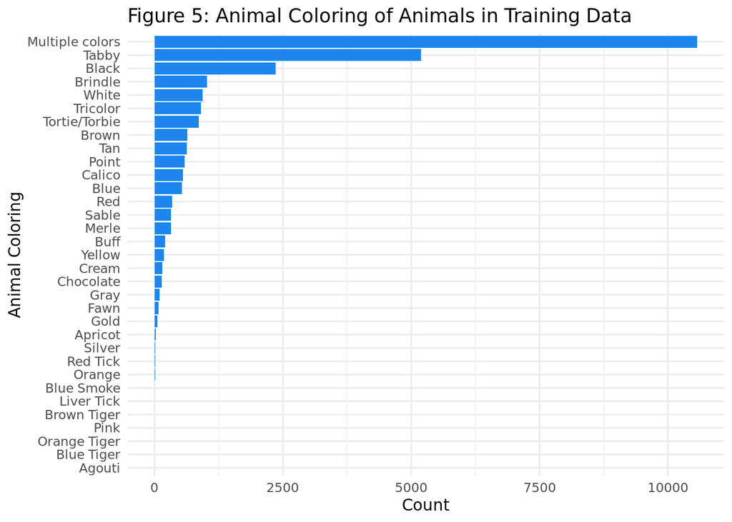

Finally, the date that the given outcome took place is recorded. The first outcome occurred on October 1st, 2013, while the final outcome occurred on February 21st, 2016. The date as a whole was not useful for prediction, however I extracted both the month and the year of the outcome for each pet, as they could be helpful predictor variables. It’s possible that more pets are adopted during the holidays, or that the number of pets experiencing any outcome is different from year to year.

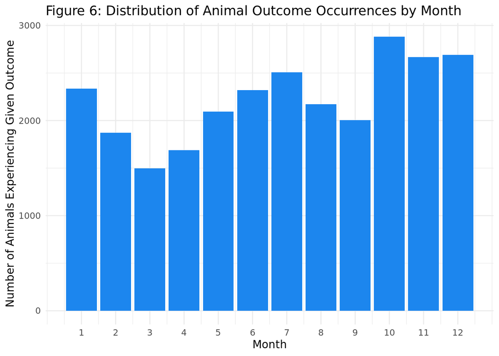

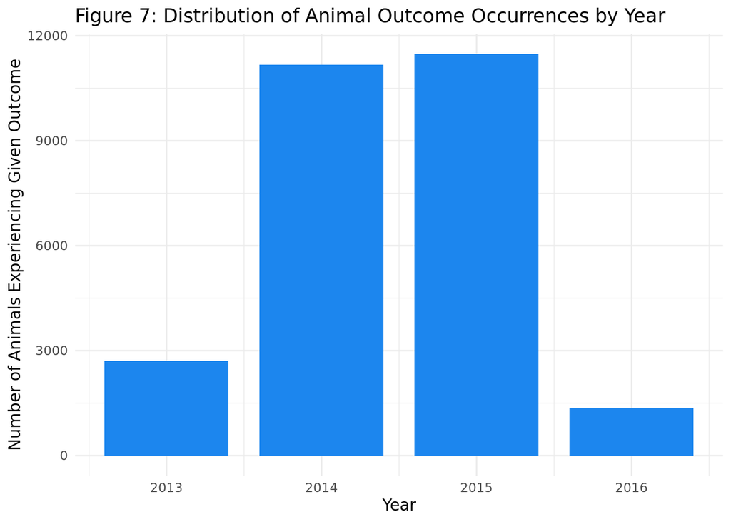

All code used to preprocess the data is shown below, including the final preprocessing recipe. To gain even more potentially useful information for prediction, I also added indicator variables to the data that indicated whether the date of the outcome was a holiday, using 4 major US holidays. Many theorize that the number of adopted pets increases on holidays, since they are given as gifts to family and friends.

```r
# define working directory
dir <- getwd()

# raw data directory
dataset_dir <- dir %>%
  paste0("/datasets")

# read in training data
df <- dataset_dir %>%
  paste0("/train.csv") %>%
  read_csv() %>%
  rename(animal_id = AnimalID, animal_name = Name, outcome_datetime = DateTime,
         outcome = OutcomeType, outcome_subtype = OutcomeSubtype,
         animal_type = AnimalType, sex = SexuponOutcome,
         age = AgeuponOutcome, breed = Breed, color = Color) %>%
  relocate(outcome, .after = "animal_id")

# take a small sample of it for computation's sake
df_small <- df %>%
  slice_sample(n = 1000)

age_to_years_numeric <- function(age_char) {
  case_when(
    # if measured in years
    str_detect(age_char, pattern = "year") ~ as.double(str_extract(age_char, pattern= "\\d+")),
    # if measured in months
    str_detect(age_char, pattern = "month") ~ as.double(str_extract(age_char, pattern = "\\d+")) / 12,
    # if measured in weeks
    str_detect(age_char, pattern = "week") ~ as.double(str_extract(age_char, pattern = "\\d+")) / 52.1429,
    # if measured in days
    str_detect(age_char, pattern = "day") ~ as.double(str_extract(age_char, pattern = "\\d+")) / 365
  )
}


collapse_colors <- function(colors_fac) {
  colors_vec <- as.character(colors_fac)

  case_when(
    str_detect(colors_vec, pattern = "Tabby") ~ "Tabby",
    str_detect(colors_vec, pattern = "Point") ~ "Point",
    str_detect(colors_vec, pattern = "Brindle") ~ "Brindle",
    str_detect(colors_vec, pattern = "Calico") ~ "Calico",
    str_detect(colors_vec, pattern = "Merle") ~ "Merle",
    str_detect(colors_vec, pattern = "Tricolor") ~ "Tricolor",
    str_detect(colors_vec, pattern = "Sable") ~ "Sable",
    str_detect(colors_vec, pattern = "Blue Tick") |  str_detect(colors_vec, pattern = "Blue Cream") ~ "Blue",
    str_detect(colors_vec, pattern = "Black Smoke") ~ "Black",
    str_detect(colors_vec, pattern = "/") ~ "Multiple colors",
    str_detect(colors_vec, pattern = "Tortie") | str_detect(colors_vec, pattern = "Torbie") ~ "Tortie/Torbie",
    TRUE ~ colors_vec
  )
}

# final preprocessing recipe
preproc_rec <- recipe(outcome ~ ., data = df_small) %>%
  # set 'animal_id' as the identifier variable, not to be used in prediction
  update_role(animal_id, new_role = "id") %>%
  # data preprocessing
  step_mutate(
    # convert age to numeric
    age = age_to_years_numeric(age),
    # add month variable (as a factor)
    outcome_month = factor(month(outcome_datetime)),
    # add year variable (as a factor)
    outcome_year = factor(year(outcome_datetime)),
    # reduce number of unique animal colors
    color = factor(collapse_colors(color))
    ) %>%
  # add indicator variable for if date is a holiday
  step_holiday(outcome_datetime,
               holidays = c("ChristmasEve", "NewYearsDay", "USChristmasDay",
                            "USThanksgivingDay")) %>%
  # remove columns that are no longer useful
  step_rm(outcome_datetime, breed, animal_name, outcome_subtype)

# fit recipe to training data
preproc_prepped <- preproc_rec %>% prep(df)

# apply recipe to training data
preproc_train <- preproc_prepped %>% bake(df)

# apply recipe to test data
preproc_test <- preproc_prepped %>% bake(test_df) %>%
  mutate(animal_id = as.character(1:nrow(test_df)))

# define directory that will hold preprocessed data
preproc_dir <- dir %>%
  paste0("/preprocessed_data")

# write preprocessed training data to csv
preproc_train %>%
  write_csv(paste0(preproc_dir, "/train_preprocessed.csv"))

# write preprocessed testing data to csv
preproc_test %>%
  write_csv(paste0(preproc_dir, "/test_preprocessed.csv"))
```

## Modeling

### Setup

In order to begin the modeling process, I first read in the preprocessed data, once again using a small sample in order to make computations easier. The code for this can be seen below.

```r
# read in preprocessed training data
train_small <- preproc_dir %>%
  paste0("/train_preprocessed.csv") %>%
  read_csv() %>%
  mutate(
    animal_type = factor(animal_type),
    sex = factor(sex),
    color = factor(color),
    outcome = factor(outcome),
    outcome_month = factor(outcome_month),
    outcome_year = factor(outcome_year),
    mix = factor(mix)
  ) %>%
  slice_sample(n = 2000)

# create 5 cross-validation folds
train_cv <- vfold_cv(train_small, v = 5, strata = outcome)
```

Next, I wrote a recipe to prepare the data for fitting. The only numeric variable, age, was normalized for the sake of simplicity, and also because normalization is important in some models such as neural networks. Later in the modeling process, I ran into problems where certain variables had a variance of 0 within a outcome group. To attempt to combat this, I added a step in the recipe that drops variables with zero or near-zero variance. Finally, all factor variables were converted to indicator variables, since most models only take in numeric data.

```r
animal_rec <- recipe(outcome ~ ., data = train_small) %>%
  update_role(animal_id, new_role = "ID") %>%
  # fill missing categorical values based on mode
  step_impute_mode(all_nominal_predictors()) %>%
  # fill missing numeric values based on median
  step_impute_median(age) %>%
  # normalize the age variable
  step_normalize(age) %>%
  # remove variables that have zero or near-zero variance
  step_nzv(mix) %>%
  # convert factor variables to dummy variables
  step_dummy(all_nominal_predictors())
```

### Specifying Models

To begin the modeling process, I first wanted to get some baseline results. So, I tried 12 different classification models that can handle more than two classes, which I grouped into the categories shown in Table 1 below.

**Table 1**

| category | Number of models | models |
| --- | --- | --- |
| basic | 2 | KNN, flexible LDA |
| ensemble | 3 | bagged decision tree, random forest, boosted tree |
| rule-based | 2 | decision tree, C5.0 rules |
| svm | 2 | SVM, SVM w/ RBF kernel |
| other | 3 | multinomial regression, naive bayes, MLP |

### Getting Baseline Cross-Validated Results

Next, I evaluated all 12 models based on 5-fold cross-validated accuracy and ROC-AUC. The results are shown in Figure 8 below.

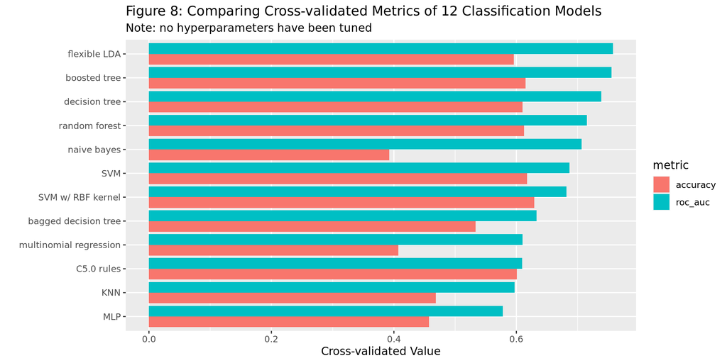

The next step was to optimize the chosen models, tuning their hyperparameters to maximize ROC-AUC.

### Tuning Chosen Models

The code for tuning all four models is shown below:

**Flexible LDA:**

```r
# Notes:

  # Wasn't able to tune `num_terms` because using anything less than all 58 columns results in matrix singularity issues.

  # All pruning methods except "backward" and "none" were incompatible with anything but binary classification

# define tuning spec
lda_flex_tune <- discrim_flexible(prod_degree = tune(),
                                  prune_method = tune()) %>%
  set_engine("earth") %>%
  set_mode("classification")

# add to workflow
lda_tune_wflow <- workflow() %>%
  add_recipe(animal_rec) %>%
  add_model(lda_flex_tune)

# manually define hyperparameter space
lda_tune_grid <- expand.grid(prod_degree = c(1, 2), prune_method = c("backward", "none"))

# tune model
lda_tune_gs <- tune_grid(
  lda_tune_wflow,
  resamples = train_cv,
  grid = lda_tune_grid
)

# extract combination that maximizes ROC-AUC
best_lda_attrs <- lda_tune_gs %>%
  collect_metrics() %>%
  filter(.metric == "roc_auc") %>%
  slice_max(mean) %>%
  slice_tail()

# value = 1
best_prod_degree <- best_lda_attrs %>%
  pull(prod_degree)

# value = "backward"
best_prune_method <- best_lda_attrs %>%
  pull(prune_method)


# define tuned model
best_lda_flex_spec <- discrim_flexible(prod_degree = best_prod_degree,
                                       prune_method = best_prune_method) %>%
  set_engine("earth") %>%
  set_mode("classification")

# add to workflow
best_lda_flex_wflow <- workflow() %>%
  add_recipe(animal_rec) %>%
  add_model(best_lda_flex_spec)
```

**Decision Tree**

```r
# define tuning spec
dtree_tune <- decision_tree(cost_complexity = tune(),
                            tree_depth = tune(),
                            min_n = tune()) %>%
  set_engine("rpart") %>%
  set_mode("classification")

# add to workflow
dtree_tune_wflow <- workflow() %>%
  add_recipe(animal_rec) %>%
  add_model(dtree_tune)

# define hyperparameter space
dtree_tune_grid <- grid_regular(cost_complexity(),
                                tree_depth(),
                                min_n(),
                                levels = 3)

# tune model
dtree_tune_gs <- tune_grid(
  dtree_tune_wflow,
  resamples = train_cv,
  grid = dtree_tune_grid
)

# extract combination that maximizes ROC-AUC
best_dtree_attrs <- dtree_tune_gs %>%
  collect_metrics() %>%
  filter(.metric == "roc_auc") %>%
  slice_max(mean) %>%
  slice_tail()

# value = 3.162278e-06
best_cost_complexity <- best_dtree_attrs %>%
  pull(cost_complexity)

# value = 8
best_tree_depth <- best_dtree_attrs %>%
  pull(tree_depth)

# value = 40
best_min_n <- best_dtree_attrs %>%
  pull(min_n)

# define tuned model
best_dtree_spec <- decision_tree(cost_complexity = best_cost_complexity,
                            tree_depth = best_tree_depth,
                            min_n = best_min_n) %>%
  set_engine("rpart") %>%
  set_mode("classification")

# add to workflow
best_dtree_wflow <- workflow() %>%
  add_recipe(animal_rec) %>%
  add_model(best_dtree_spec)
```

**Boosted Tree**

Tuning individual tree parameters:

```r
# define tuning spec
btree_tune1 <- boost_tree(mtry = tune(),
                          min_n = tune(),
                          tree_depth = tune()) %>%
  set_engine("xgboost") %>%
  set_mode("classification")

# add to workflow
btree_tune1_wflow <- workflow() %>%
  add_recipe(animal_rec) %>%
  add_model(btree_tune1)

# define hyperparameter space
btree_tune1_grid <- grid_regular(mtry(c(1, ncol(train_proc))),
                                 min_n(),
                                 tree_depth(),
                                 levels = 3
                                 )

# tune model
btree_tune1_gs <- tune_grid(
  btree_tune1_wflow,
  resamples = train_cv,
  grid = btree_tune1_grid
)

# extract combination that maximizes ROC-AUC
best_btree_tune1 <- btree_tune1_gs %>%
  collect_metrics() %>%
  filter(.metric == "roc_auc") %>%
  slice_max(mean) %>%
  slice_tail()

# value = 58
best_mtry <- best_btree_tune1 %>%
  pull(mtry)

# value = 2
best_min_n <- best_btree_tune1 %>%
  pull(min_n)

# value = 8
best_tree_depth <- best_btree_tune1 %>%
  pull(tree_depth)
```

Tuning boosting parameters:

```r
# define tuning spec, inputting previously tuned hyperparameters
btree_tune2 <- boost_tree(mtry = best_mtry,
                          min_n = best_min_n,
                          tree_depth = best_tree_depth,
                          trees = tune(),
                          learn_rate = tune()) %>%
  set_engine("xgboost") %>%
  set_mode("classification")

# add to workflow
btree_tune2_wflow <- workflow() %>%
  add_recipe(animal_rec) %>%
  add_model(btree_tune2)

# define remaining hyperparameter space
btree_tune2_grid <- grid_regular(trees(),
                                 learn_rate(),
                                 levels = 2
                                 )

# tune model
btree_tune2_gs <- tune_grid(
  btree_tune2_wflow,
  resamples = train_cv,
  grid = btree_tune2_grid
)

# extract combination that maximizes ROC-AUC
best_btree_tune2 <- btree_tune2_gs %>%
  collect_metrics() %>%
  filter(.metric == "roc_auc") %>%
  slice_max(mean) %>%
  slice_tail()

# value = 2000
best_num_trees <- best_btree_tune2 %>%
  pull(trees)

# value = 0.1
best_learn_rate <- best_btree_tune2 %>%
  pull(learn_rate)

# define tuned model
best_btree_spec <- boost_tree(mtry = best_mtry,
                              min_n = best_min_n,
                              tree_depth = best_tree_depth,
                              trees = best_num_trees,
                              learn_rate = best_learn_rate) %>%
  set_engine("xgboost") %>%
  set_mode("classification")

# add to workflow
best_btree_wflow <- workflow() %>%
  add_recipe(animal_rec) %>%
  add_model(best_btree_spec)
```

**Random Forest**

```r
rforest_tune <- rand_forest(mtry = tune(),
                            trees = tune(),
                            min_n = tune()) %>%
  set_engine("randomForest") %>%
  set_mode("classification")

rforest_tune_wflow <- workflow() %>%
  add_recipe(animal_rec) %>%
  add_model(rforest_tune)

rforest_tune_grid <- grid_regular(mtry(c(1, ncol(train_proc) - 2)),
                              dials::trees(),
                              min_n(),
                              levels = 2
                              )

rforest_tune_gs <- tune_grid(
  rforest_tune_wflow,
  resamples = train_cv,
  grid = rforest_tune_grid
)

best_rforest_attrs <- rforest_tune_gs %>%
  collect_metrics() %>%
  filter(.metric == "roc_auc") %>%
  slice_max(mean) %>%
  slice_tail()

# value = 58
best_mtry <- best_rforest_attrs %>%
  pull(mtry) %>%
  subtract(2)

# value = 2000
best_trees <- best_rforest_attrs %>%
  pull(trees)

# value = 40
best_min_n <- best_rforest_attrs %>%
  pull(min_n)

best_rforest_spec <- rand_forest(mtry = best_mtry,
                                 trees = best_trees,
                                 min_n = best_min_n) %>%
  set_engine("randomForest") %>%
  set_mode("classification")

best_rforest_wflow <- workflow() %>%
  add_recipe(animal_rec) %>%
  add_model(best_rforest_spec)
```

### Comparing Tuned Models

Once all models had been adequately tuned, I compared them based on ROC-AUC, accuracy, precision, recall, and F1 score. The comparison is visualized in Figure 9 below.

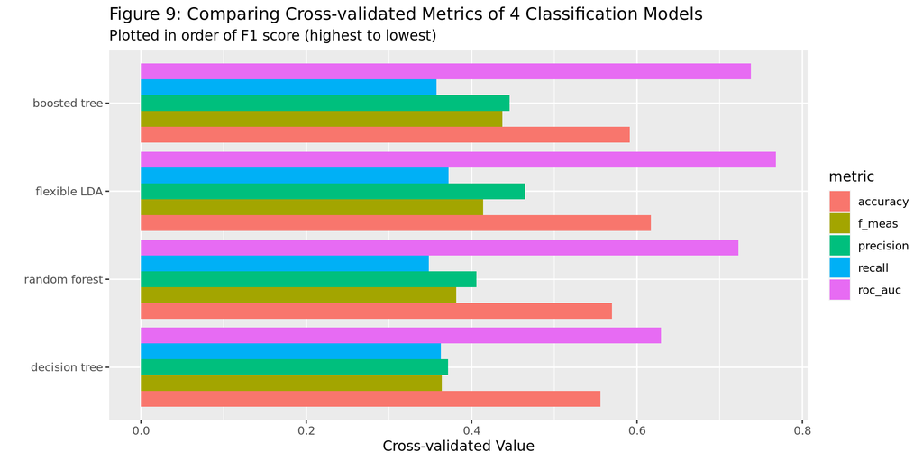

For choosing my final model, I chose F1 score as the criteria. Because the five outcomes are so unbalanced (see Figure 1, 75% of pets are either adopted or transferred), using accuracy would not be valid, since a model could theoretically achieve 75% accuracy be guessing only ‘Adoption’ or ‘Transfer’, ignoring all other outcomes. F1 score is the harmonic mean of precision and recall, so it provides a great measure of the model’s performance, and is aggregated across all five outcomes. The model with the highest F1 score was the boosted tree.

A confusion matrix for the boosted tree model is shown in Table 2 below.

**Table 2**

```
##                  Truth
## Prediction        Adoption Died Euthanasia Return_to_owner Transfer
##   Adoption            9152   23        286            2052     2348
##   Died                   0    0          0               0        0
##   Euthanasia            20    3        203              66       84
##   Return_to_owner      966   12        325            2105      776
##   Transfer             631  159        741             563     6214
```

Table 2 shows that the boosted tree did not actually predict that any pets died. This is most likely because only 0.75% of the pets in the training data actually died, so there was not much information unique to those pets, compared to pets that experienced other outcomes. Another way to think about it is that if the model decides never to guess ‘Died’ as an outcome, the only consequence is potentially a 0.75% decrease in training accuracy.

### Formatting and Outputting Results

Finally, the chosen model was fit the the entirity of the training data:

```r
final_fit <- best_btree_wflow %>%
  fit(train)
```

The submission requested that the class probabilities be reported for each pet, which required some data manipulation, shown below

```r
# define directory that holds submission files
submission_dir <- dir %>%
  paste0("/submissions")

submission <- final_fit %>%
  predict(new_data = test, type = "prob") %>%
  rename_with(~str_remove(.x, pattern = ".pred_")) %>%
  add_column(ID = 1:nrow(test), .before = "Adoption")

# write submission to csv
submission %>%
  write_csv(file = paste0(submission_dir, "/submission2.csv"))

# print out some of the submission file
submission %>%
  head() %>%
  knitr::kable()
```

| ID | Adoption | Died | Euthanasia | Return_to_owner | Transfer |
| --- | --- | --- | --- | --- | --- |
| 1 | 0.0496806 | 0.0103515 | 0.0549166 | 0.1249389 | 0.7601123 |
| 2 | 0.6658495 | 0.0117370 | 0.0326976 | 0.1899474 | 0.0997685 |
| 3 | 0.3454610 | 0.0125339 | 0.0199115 | 0.0599144 | 0.5621792 |
| 4 | 0.0593591 | 0.0126931 | 0.0580052 | 0.1292463 | 0.7406963 |
| 5 | 0.4205533 | 0.0153465 | 0.0270791 | 0.2933485 | 0.2436726 |
| 6 | 0.3083407 | 0.0129897 | 0.0518402 | 0.4842925 | 0.1425369 |

### Submitting Results

After getting the submission in the proper format, I submitted my results to Kaggle.

According to the competition page:

As you can see below, I achieved a score of 0.88103. The best score achieved was 0.34093.

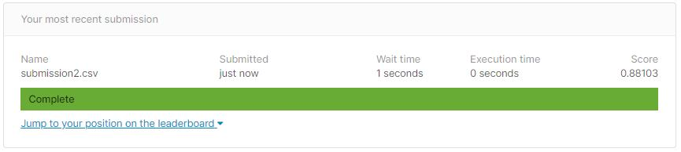